# Happiness & Open Data (II)

Bourbon0212

2018年7月25日

- [Happiness & Open Data (I)](https://bourbon0212.github.io/NTU-CS-X/Week3/Happiness_and_Open_Data.html)
- Preparation
- Analysis
  - Openness & Region
  - Happiness & Region
  - GDP & Region
  - Happiness & GDP
- Conclusion

# **Preparation**

```r
# Export the data we've collected from (I) to a csv
write.table(data_table, file = "data.CSV", sep = ",")
```

```r
# Import data
library(formattable)
library(dplyr)
setwd("D:/GitHub/NTU-CS-X/Week4")
data <- read.csv('./data.csv')
data %>%
  formattable(align = "l") %>%
  head(5)
```

| Country | Region | Openness | Happiness | GDP | Family | Health | Freedom | Trust | Generosity | DystopiaResidual |
| --- | --- | --- | --- | --- | --- | --- | --- | --- | --- | --- |
| Taiwan | Eastern Asia | 78 | 6.30 | 1.29 | 1.08 | 0.88 | 0.40 | 0.08 | 0.25 | 2.32 |
| United Kingdom | Western Europe | 76 | 6.87 | 1.27 | 1.29 | 0.91 | 0.60 | 0.32 | 0.52 | 1.97 |
| Denmark | Western Europe | 70 | 7.53 | 1.33 | 1.36 | 0.87 | 0.65 | 0.48 | 0.34 | 2.49 |
| Colombia | Latin America and Caribbean | 68 | 6.48 | 0.92 | 1.24 | 0.69 | 0.53 | 0.05 | 0.18 | 2.86 |
| Finland | Western Europe | 67 | 7.41 | 1.29 | 1.32 | 0.89 | 0.64 | 0.41 | 0.23 | 2.62 |

# **Analysis**

## **Openness & Region**

### Errorbar Plot

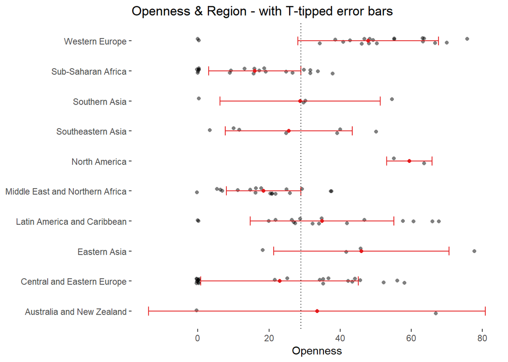

```r
library(ggplot2)
library(Hmisc)
data <- filter(data, !is.na(Region))
data %>%
  ggplot(aes(x = Region, y = Openness)) +
    geom_jitter(shape = 16, width = 0.1, alpha = 0.5) +
    stat_summary(geom = 'point', fun.y = mean, col = '#E41A1C') +
    # fun.args = list(mult = 1) to have a errorbar that spans over one standard deviation in both directions.
    stat_summary(geom = 'errorbar', fun.data = mean_sdl, fun.args = list(mult = 1),
                 width = 0.3, col = '#E41A1C') +
    labs(y = 'Openness', title = 'Openness & Region - with T-tipped error bars') +
    theme(axis.title.y = element_blank(), panel.grid = element_blank(), panel.background = element_blank()) +
    geom_hline(yintercept = mean(data$Openness), linetype = 'dotted') +
    coord_flip()
```

### ANOVA

```r
anova(lm(Openness ~ Region, data = data))
```

```
## Analysis of Variance Table
##
## Response: Openness
##            Df Sum Sq Mean Sq F value    Pr(>F)
## Region      9  17245 1916.08  5.5159 3.129e-06 ***
## Residuals 108  37517  347.38
## ---
## Signif. codes:  0 '***' 0.001 '**' 0.01 '*' 0.05 '.' 0.1 ' ' 1
```

According to this plot & anova test, we can conclude that:

- Since `Pr(>F)` < `0.05`, the mean of each grop has significant difference.
- In `Sub-Saharan Africa` and `Central and Easttern Europe` the openness of some countries are `0`.
- It’s obvious that `Region` has noting to do with `Openness` in Ocenia.

### Regression

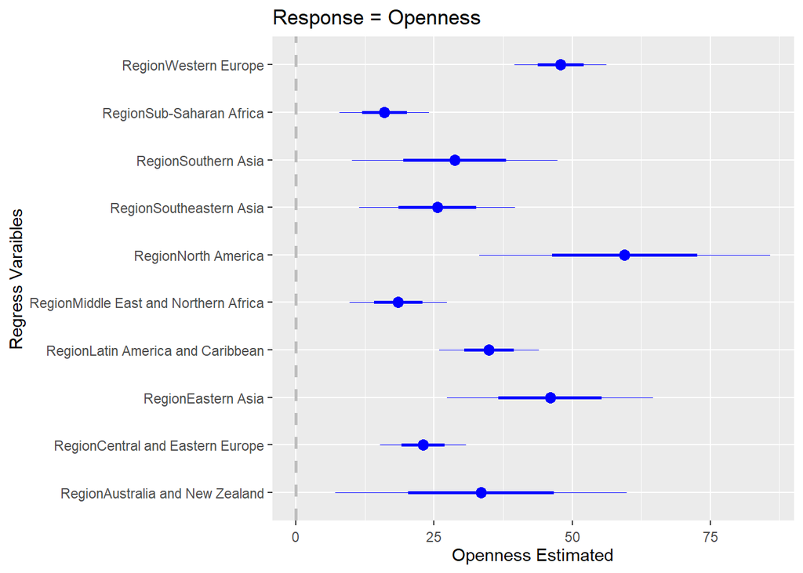

```r
library(coefplot)
m1 <- lm(Openness ~ Region - 1,
         data = data)
coefplot(m1, xlab = 'Openness Estimated', ylab = 'Regress Varaibles', title = 'Response = Openness')
```

```r
# 把資料與迴歸分析的預測值、殘差與影響度放進資料
fit_m1 <- data.frame(data[, c("Region","Openness")], fitted = fitted(m1), resid = resid(m1),
                     infl = influence(m1)$hat)
```

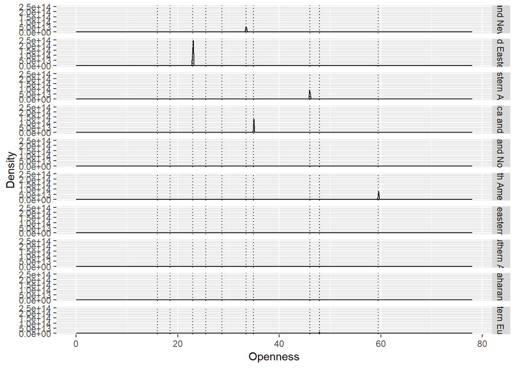

```r
# 依地區疊合真實觀測值與預測值
ggplot(data = fit_m1, aes(x = Openness, group = Region )) +
 stat_density(geom = 'path', position = 'identity') +
 stat_density(geom = 'path', position = 'identity', aes(x = fitted)) +
 geom_vline(xintercept = c(with(data, tapply(Openness,Region, mean))), linetype = 'dotted')+
 facet_grid(Region ~ .) +
 labs(x = 'Openness', y = 'Density')
```

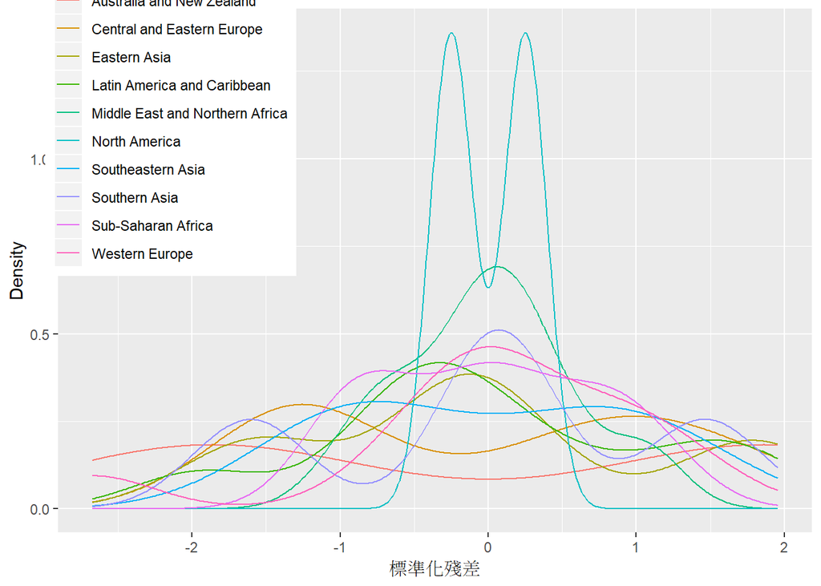

```r
# 看殘差分配，依快樂指數，檢視常態與變異數同質假設
ggplot(data = fit_m1, aes(x = scale(resid)), group = Region ) +
 stat_density(geom = 'path', position = 'identity', aes(col = Region)) +
 scale_linetype_manual(values = 10:1) +
 guides(linetype = guide_legend(reverse = TRUE)) +
 labs(x = '標準化殘差', y = 'Density') +
 theme(legend.position = c(.15, .8))
```

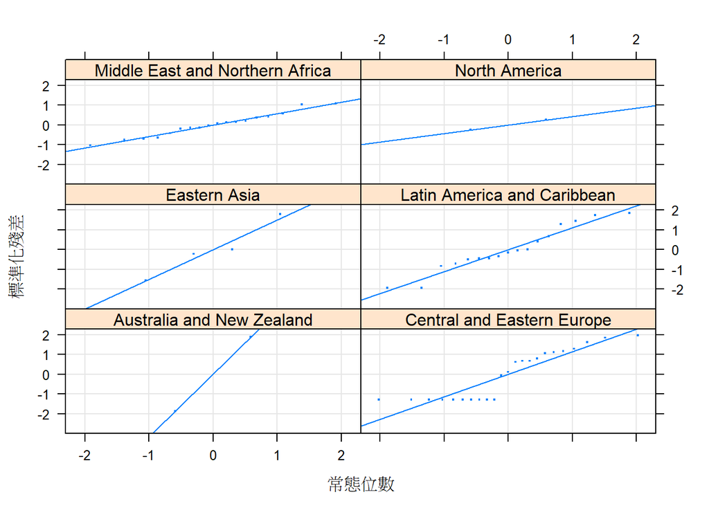

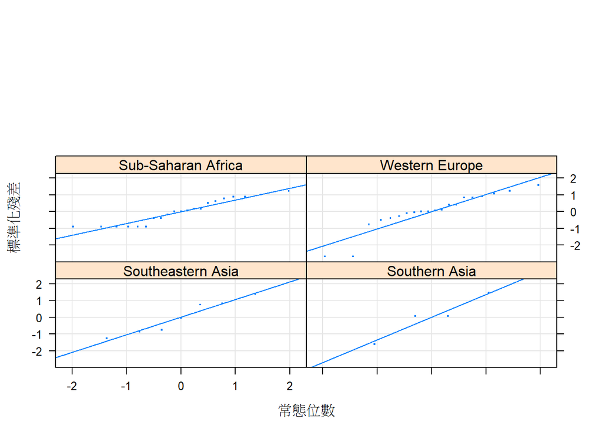

```r
library(lattice)
# 看看殘差的 Q-Q 圖，依快樂指數。檢視常態假設
qqmath(~ scale(resid) | Region, data = fit_m1, type = c('p', 'g', 'r'),
       xlab = '常態位數', ylab = '標準化殘差', layout = c(2, 3),
       pch = '.', cex = 2)
```

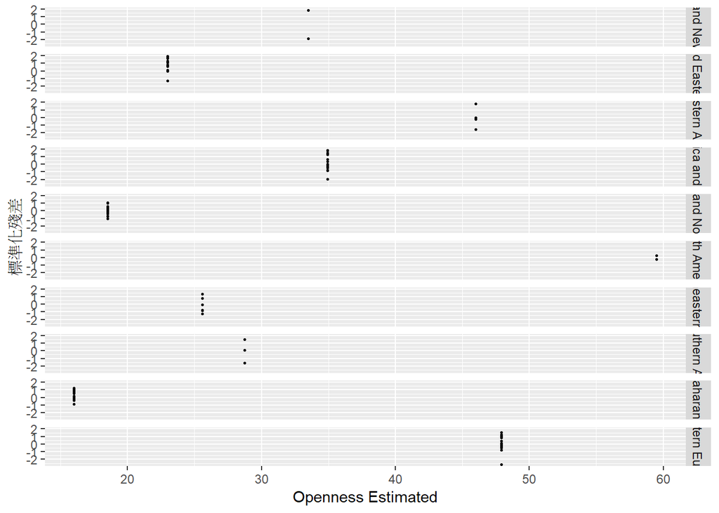

```r
library(MASS)
# 畫預測值與殘差的散佈圖，檢查線性與等分散假設
ggplot(data = fit_m1, aes(x = fitted, y = scale(resid), group = Region )) +
  geom_point(pch = 20, size = 1) +
  stat_smooth(method = 'rlm', se = F) +
  facet_grid(Region ~ .) +
  labs(x = 'Openness Estimated', y = '標準化殘差')
```

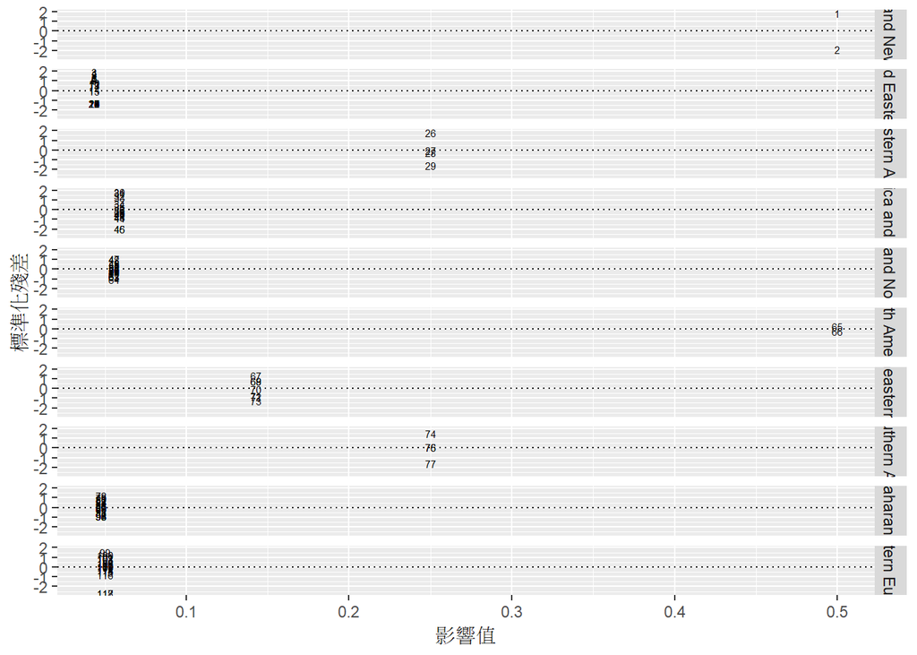

```r
# 呈現影響值（影響估計結果過大的值）與標準化殘差
ggplot(data = fit_m1, aes(x = infl, y = scale(resid), group = Region)) +
 geom_text(aes(label = rownames(fit_m1)), cex = 2) +
 geom_hline(yintercept = 0, linetype = 'dotted') +
 facet_grid(Region ~ .) +
 labs(x = '影響值', y = '標準化殘差')
```

```r
# 看看影響值
summary(influence(m1)$hat)
```

```
##    Min. 1st Qu.  Median    Mean 3rd Qu.    Max.
## 0.04348 0.04762 0.05000 0.08475 0.05882 0.50000
```

## **Happiness & Region**

### Errorbar Plot

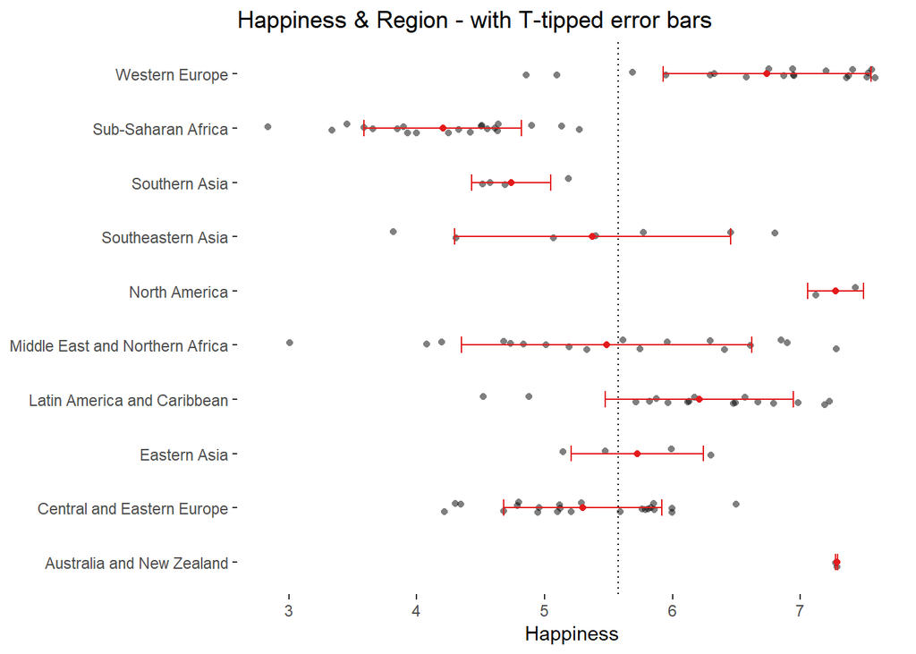

```r
data %>%
  ggplot(aes(x = Region, y = Happiness)) +
    geom_jitter(shape = 16, width = 0.1, alpha = 0.5) +
    stat_summary(geom = 'point', fun.y = mean, col = '#E41A1C') +
    stat_summary(geom = 'errorbar', fun.data = mean_sdl, fun.args = list(mult = 1),
                 width = 0.3, col = '#E41A1C') +
    labs(y = 'Happiness', title = 'Happiness & Region - with T-tipped error bars') +
    theme(axis.title.y = element_blank(), panel.grid = element_blank(), panel.background = element_blank()) +
    geom_hline(yintercept = mean(data$Happiness), linetype = 'dotted') +
    coord_flip()
```

### ANOVA

```r
anova(lm(Happiness ~ Region, data = data))
```

```
## Analysis of Variance Table
##
## Response: Happiness
##            Df Sum Sq Mean Sq F value    Pr(>F)
## Region      9 90.116 10.0129  16.085 < 2.2e-16 ***
## Residuals 108 67.228  0.6225
## ---
## Signif. codes:  0 '***' 0.001 '**' 0.01 '*' 0.05 '.' 0.1 ' ' 1
```

According to this plot & anova test, we can conclude that:

- Since `Pr(>F)` < `0.05`, the mean of each grop has significant difference.
- Oceanian are the happiest people of all the regions.
- The countries of `Happiness` in `SouthEastern Asia` & `Middle East & Northern Africa` are the least centralized.

### Regression

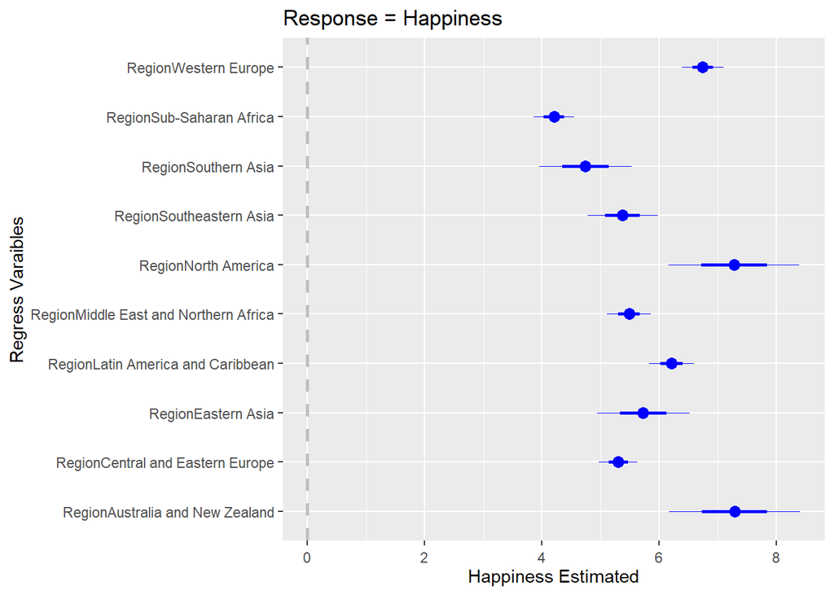

```r
library(coefplot)
m2 <- lm(Happiness ~ Region - 1,
         data = data)
coefplot(m2, xlab = 'Happiness Estimated', ylab = 'Regress Varaibles', title = 'Response = Happiness')
```

```r
# 把資料與迴歸分析的預測值、殘差與影響度放進資料
fit_m2 <- data.frame(data[, c("Region","Happiness")], fitted = fitted(m2), resid = resid(m2),
                     infl = influence(m2)$hat)
```

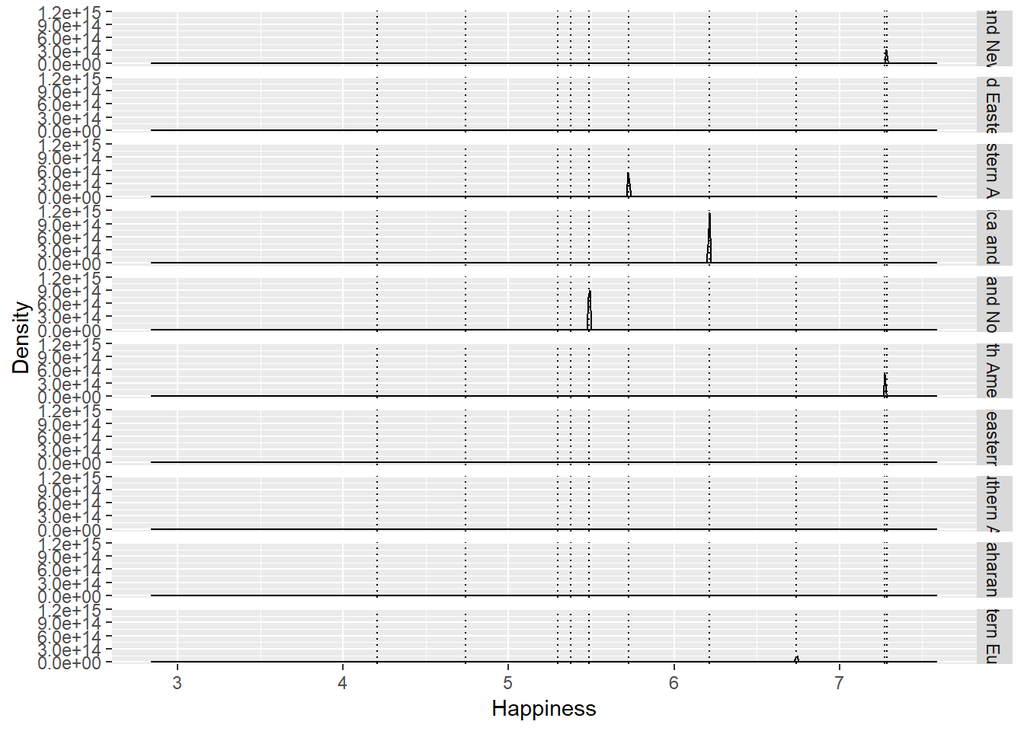

```r
# 依地區疊合真實觀測值與預測值
ggplot(data = fit_m2, aes(x = Happiness, group = Region )) +
 stat_density(geom = 'path', position = 'identity') +
 stat_density(geom = 'path', position = 'identity', aes(x = fitted)) +
 geom_vline(xintercept = c(with(data, tapply(Happiness,Region, mean))), linetype = 'dotted')+
 facet_grid(Region ~ .) +
 labs(x = 'Happiness', y = 'Density')
```

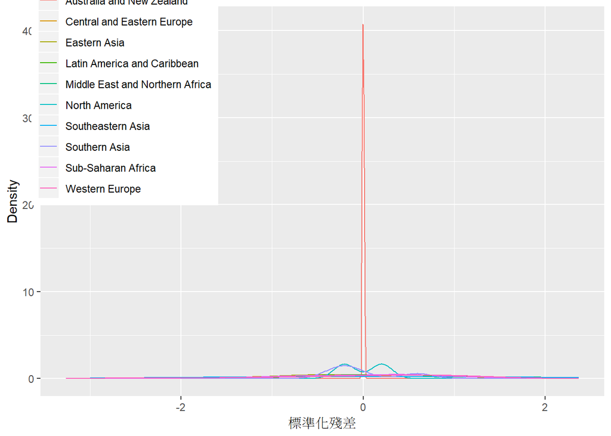

```r
# 看殘差分配，依快樂指數，檢視常態與變異數同質假設
ggplot(data = fit_m2, aes(x = scale(resid)), group = Region ) +
 stat_density(geom = 'path', position = 'identity', aes(col = Region)) +
 scale_linetype_manual(values = 10:1) +
 guides(linetype = guide_legend(reverse = TRUE)) +
 labs(x = '標準化殘差', y = 'Density') +
 theme(legend.position = c(.15, .8))
```

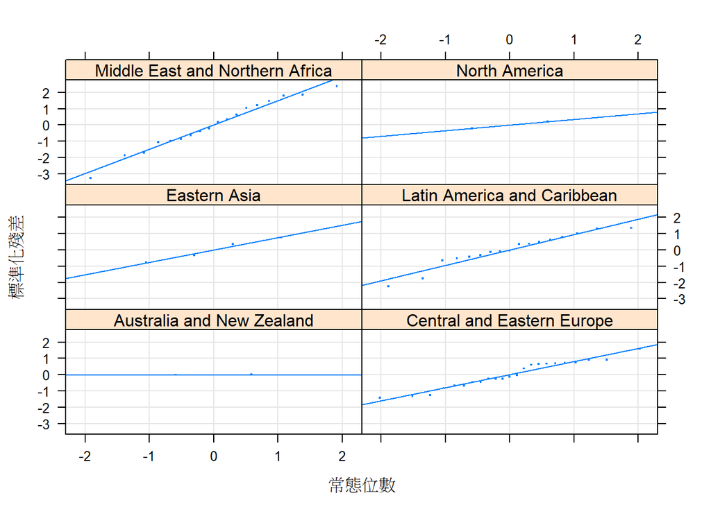

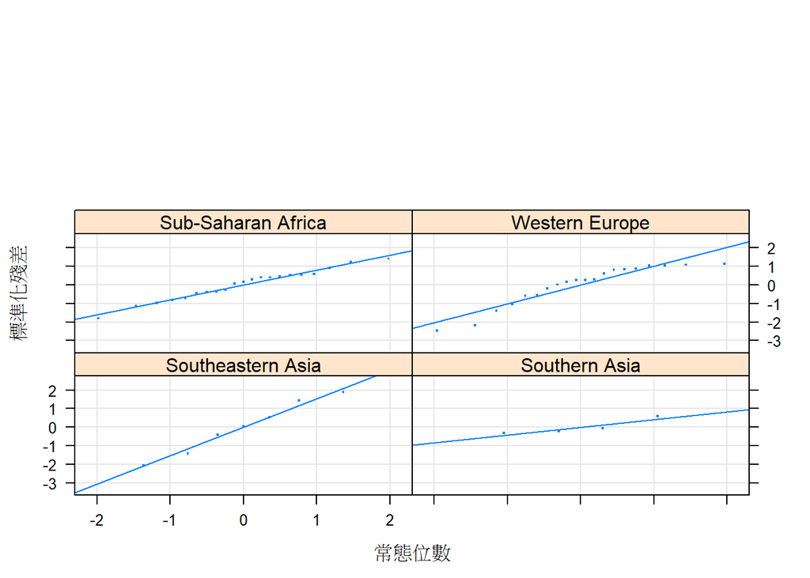

```r
library(lattice)
# 看看殘差的 Q-Q 圖，依快樂指數。檢視常態假設
qqmath(~ scale(resid) | Region, data = fit_m2, type = c('p', 'g', 'r'),
       xlab = '常態位數', ylab = '標準化殘差', layout = c(2, 3),
       pch = '.', cex = 2)
```

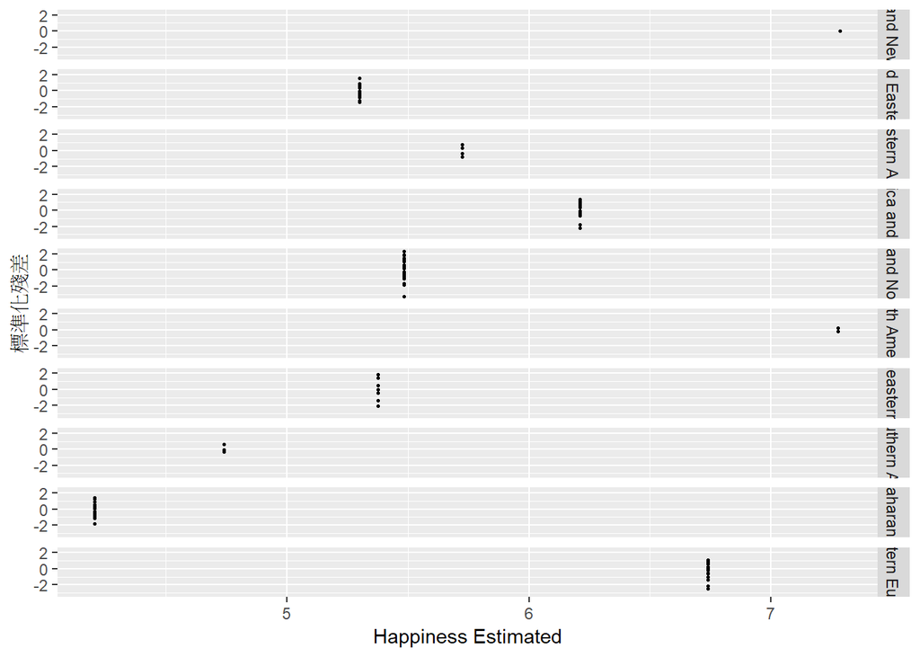

```r
library(MASS)
# 畫預測值與殘差的散佈圖，檢查線性與等分散假設
ggplot(data = fit_m2, aes(x = fitted, y = scale(resid), group = Region )) +
  geom_point(pch = 20, size = 1) +
  stat_smooth(method = 'rlm', se = F) +
  facet_grid(Region ~ .) +
  labs(x = 'Happiness Estimated', y = '標準化殘差')
```

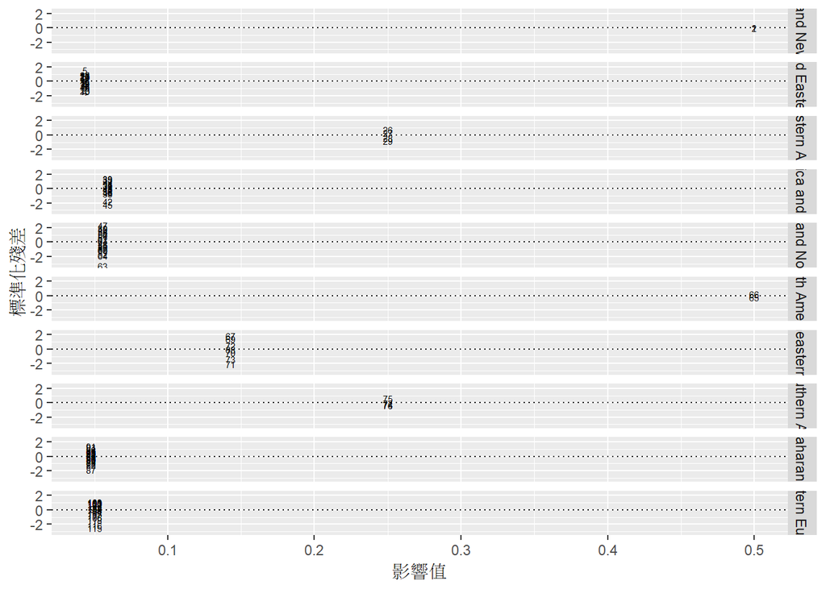

```r
# 呈現影響值（影響估計結果過大的值）與標準化殘差
ggplot(data = fit_m2, aes(x = infl, y = scale(resid), group = Region)) +
 geom_text(aes(label = rownames(fit_m2)), cex = 2) +
 geom_hline(yintercept = 0, linetype = 'dotted') +
 facet_grid(Region ~ .) +
 labs(x = '影響值', y = '標準化殘差')
```

```r
# 看看影響值
summary(influence(m2)$hat)
```

```
##    Min. 1st Qu.  Median    Mean 3rd Qu.    Max.
## 0.04348 0.04762 0.05000 0.08475 0.05882 0.50000
```

## **GDP & Region**

### Errorbar Plot

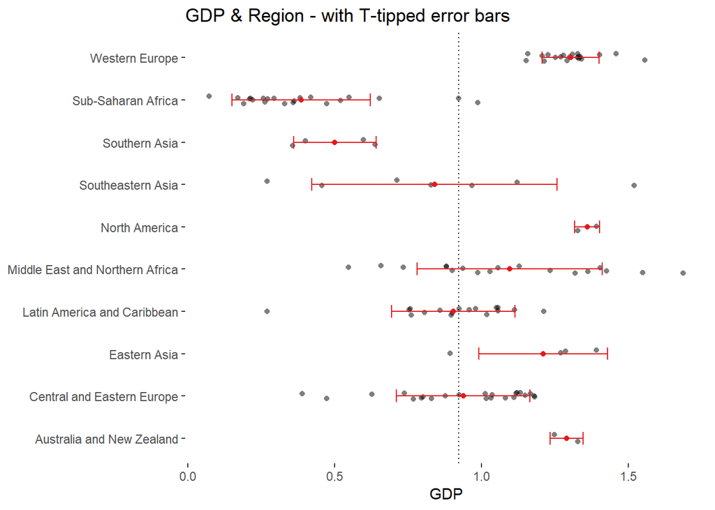

```r
data %>%
  ggplot(aes(x = Region, y = GDP)) +
    geom_jitter(shape = 16, width = 0.1, alpha = 0.5) +
    stat_summary(geom = 'point', fun.y = mean, col = '#E41A1C') +
    stat_summary(geom = 'errorbar', fun.data = mean_sdl, fun.args = list(mult = 1),
                 width = 0.3, col = '#E41A1C') +
    labs(y = 'GDP', title = 'GDP & Region - with T-tipped error bars') +
    theme(axis.title.y = element_blank(), panel.grid = element_blank(), panel.background = element_blank()) +
    geom_hline(yintercept = mean(data$GDP), linetype = 'dotted') +
    coord_flip()
```

### ANOVA

```r
anova(lm(GDP ~ Region, data = data))
```

```
## Analysis of Variance Table
##
## Response: GDP
##            Df  Sum Sq Mean Sq F value    Pr(>F)
## Region      9 11.2603 1.25114  22.245 < 2.2e-16 ***
## Residuals 108  6.0742 0.05624
## ---
## Signif. codes:  0 '***' 0.001 '**' 0.01 '*' 0.05 '.' 0.1 ' ' 1
```

According to this plot & anova test, we can conclude that:

- Since `Pr(>F)` < `0.05`, the mean of each grop has significant difference.
- The countries of `GDP` in `SouthEastern Asia` & `Middle East & Northern Africa` are the least centralized.
- The distribute of this plot is **similar** to the previous one.
- So I make a prediction that the correlation between `Happiness` & `GDP` is high.

### Regression

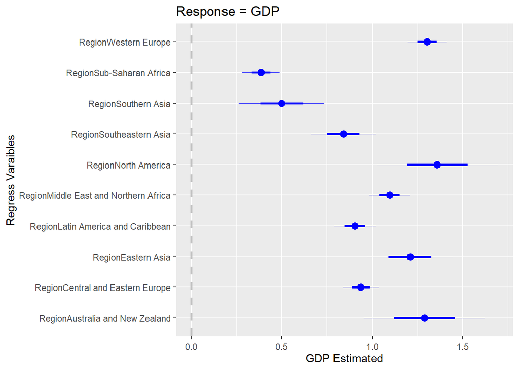

```r
library(coefplot)
m3 <- lm(GDP ~ Region - 1,
         data = data)
coefplot(m3, xlab = 'GDP Estimated', ylab = 'Regress Varaibles', title = 'Response = GDP')
```

```r
# 把資料與迴歸分析的預測值、殘差與影響度放進資料
fit_m3 <- data.frame(data[, c("Region","GDP")], fitted = fitted(m3), resid = resid(m3),
                     infl = influence(m3)$hat)
```

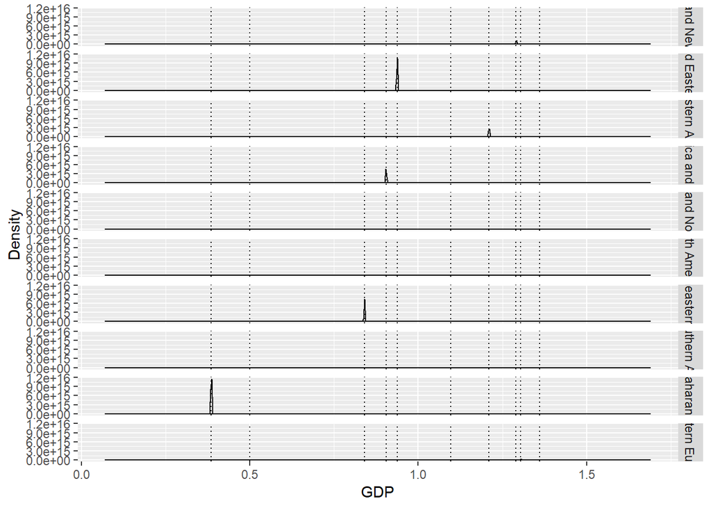

```r
# 依地區疊合真實觀測值與預測值
ggplot(data = fit_m3, aes(x = GDP, group = Region )) +
 stat_density(geom = 'path', position = 'identity') +
 stat_density(geom = 'path', position = 'identity', aes(x = fitted)) +
 geom_vline(xintercept = c(with(data, tapply(GDP,Region, mean))), linetype = 'dotted')+
 facet_grid(Region ~ .) +
 labs(x = 'GDP', y = 'Density')
```

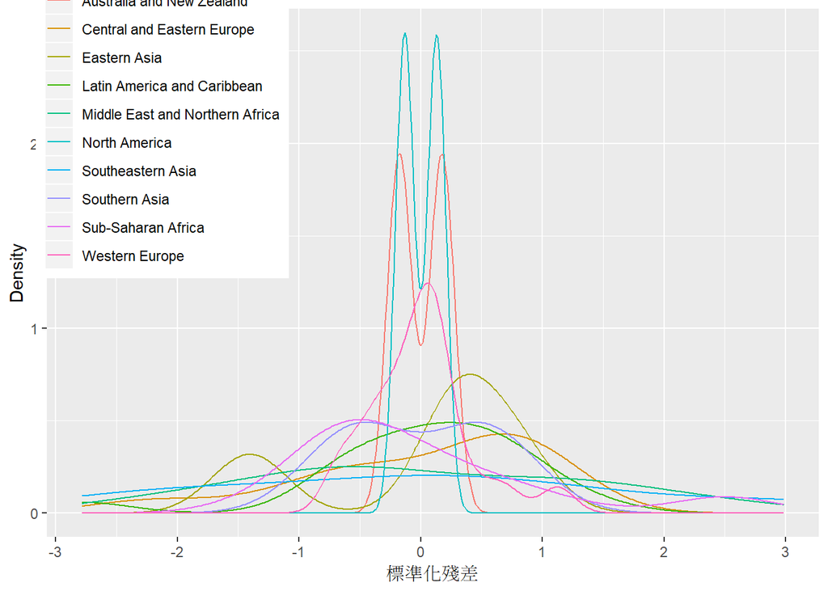

```r
# 看殘差分配，依快樂指數，檢視常態與變異數同質假設
ggplot(data = fit_m3, aes(x = scale(resid)), group = Region ) +
 stat_density(geom = 'path', position = 'identity', aes(col = Region)) +
 scale_linetype_manual(values = 10:1) +
 guides(linetype = guide_legend(reverse = TRUE)) +
 labs(x = '標準化殘差', y = 'Density') +
 theme(legend.position = c(.15, .8))
```

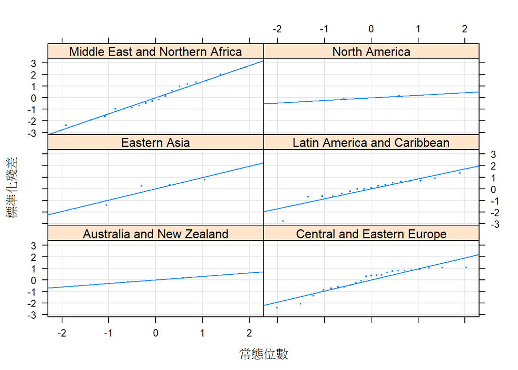

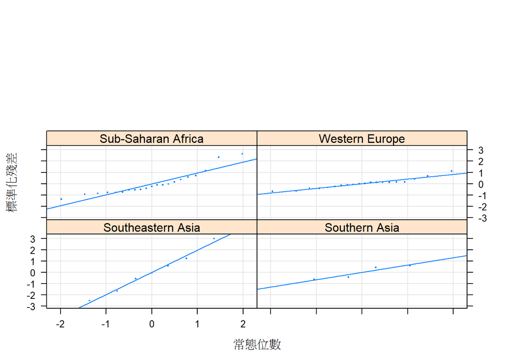

```r
library(lattice)
# 看看殘差的 Q-Q 圖，依快樂指數。檢視常態假設
qqmath(~ scale(resid) | Region, data = fit_m3, type = c('p', 'g', 'r'),
       xlab = '常態位數', ylab = '標準化殘差', layout = c(2, 3),
       pch = '.', cex = 2)
```

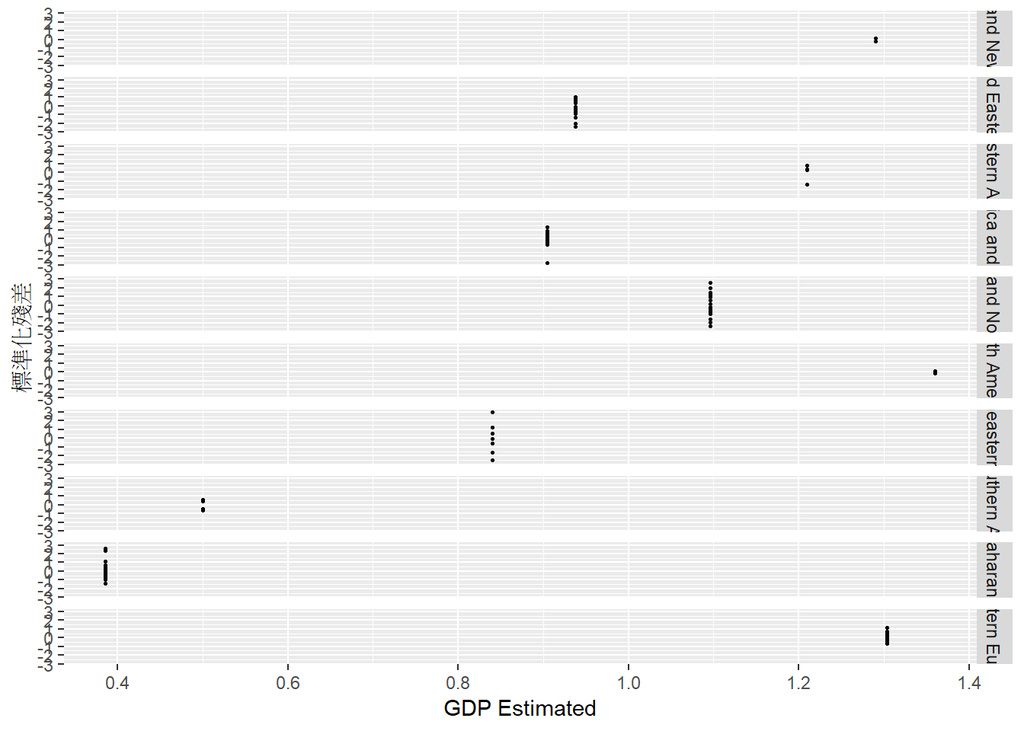

```r
library(MASS)
# 畫預測值與殘差的散佈圖，檢查線性與等分散假設
ggplot(data = fit_m3, aes(x = fitted, y = scale(resid), group = Region )) +
  geom_point(pch = 20, size = 1) +
  stat_smooth(method = 'rlm', se = F) +
  facet_grid(Region ~ .) +
  labs(x = 'GDP Estimated', y = '標準化殘差')
```

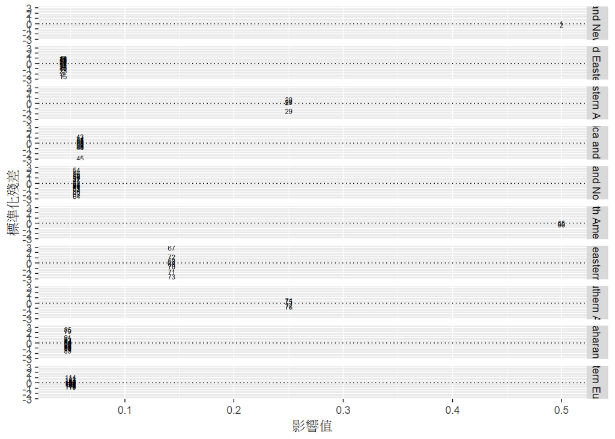

```r
# 呈現影響值（影響估計結果過大的值）與標準化殘差
ggplot(data = fit_m3, aes(x = infl, y = scale(resid), group = Region)) +
 geom_text(aes(label = rownames(fit_m3)), cex = 2) +
 geom_hline(yintercept = 0, linetype = 'dotted') +
 facet_grid(Region ~ .) +
 labs(x = '影響值', y = '標準化殘差')
```

```r
# 看看影響值
summary(influence(m3)$hat)
```

```
##    Min. 1st Qu.  Median    Mean 3rd Qu.    Max.
## 0.04348 0.04762 0.05000 0.08475 0.05882 0.50000
```

## **Happiness & GDP**

### Linear Model

Let’s draw a plot that confirmed this assumption and create the linear model of this dataset.

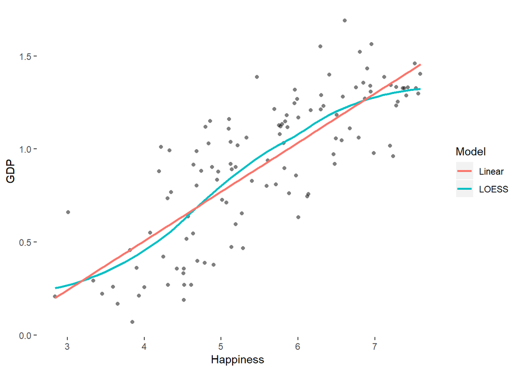

```r
data %>%
  ggplot(aes(x = Happiness, y = GDP)) +
  geom_jitter(shape = 16, alpha = 0.5) +
  stat_smooth(method = "loess", aes(col = "LOESS"), se = F) +
  stat_smooth(method = "lm", aes(col = "Linear"), se = F) +
  scale_color_discrete("Model") +
  theme(panel.grid = element_blank(), panel.background = element_blank())
```

```r
formattable(summarise(data, Observation = n(), Correlation = cor(GDP, Happiness)))
```

| Observation | Correlation |
| --- | --- |
| 118 | 0.7968557 |

The correlation here is `0.7969` which suggests that my assumption is correct.  
Here are some details of this linear model.

```r
summary(lm(GDP ~ Happiness, data = data))
```

```
##
## Call:
## lm(formula = GDP ~ Happiness, data = data)
##
## Residuals:
##      Min       1Q   Median       3Q      Max
## -0.45080 -0.15108  0.00663  0.16094  0.49528
##
## Coefficients:
##             Estimate Std. Error t value Pr(>|t|)
## (Intercept) -0.55205    0.10602  -5.207 8.41e-07 ***
## Happiness    0.26449    0.01862  14.205  < 2e-16 ***
## ---
## Signif. codes:  0 '***' 0.001 '**' 0.01 '*' 0.05 '.' 0.1 ' ' 1
##
## Residual standard error: 0.2336 on 116 degrees of freedom
## Multiple R-squared:  0.635,  Adjusted R-squared:  0.6318
## F-statistic: 201.8 on 1 and 116 DF,  p-value: < 2.2e-16
```

We can also facet the plot according to different region.  
Except those regions with only one or two countries, the correlation between `GDP` & `Happiness` are positive.

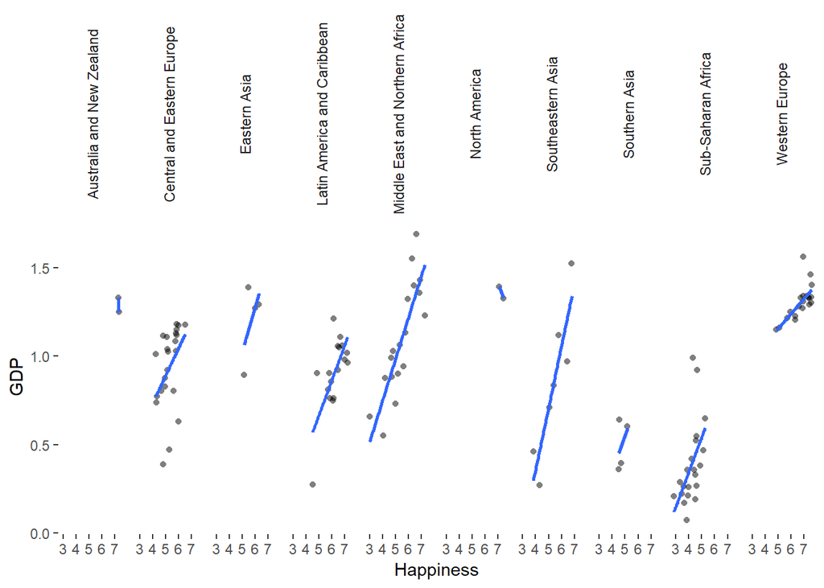

```r
ggplot(data, aes(x = Happiness, y = GDP, group = Region)) +
  geom_jitter(shape = 16, alpha = 0.5) +
  geom_smooth(method = 'lm', se = F) +
  facet_grid(.~Region) +
  theme(strip.text.x = element_text(angle = 90), strip.background = element_blank(),
        panel.grid = element_blank(), panel.background = element_blank())
```

Now, we’re going to analysis whether other factors have influence on `GDP` or not.

```r
analysis<-data[,c("GDP","Happiness","Openness","Freedom","Trust","Health")]
# 看看基本統計量
colMeans(analysis)
```

```
##        GDP  Happiness   Openness    Freedom      Trust     Health
##  0.9227119  5.5758475 28.9322034  0.4449153  0.1514407  0.6785593
```

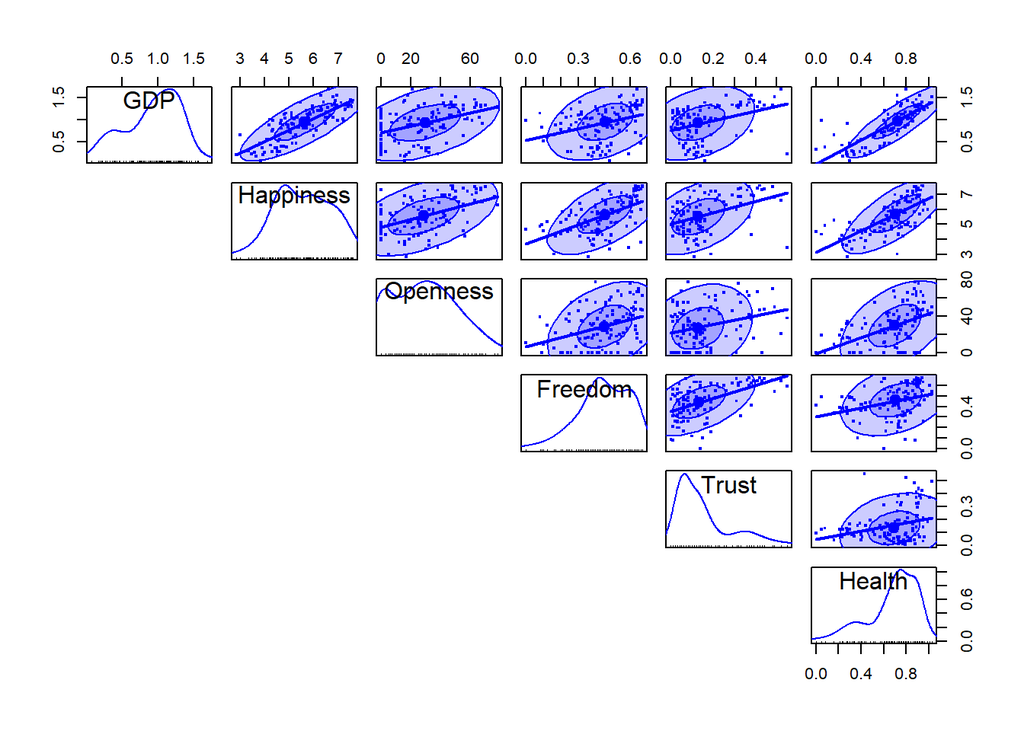

```r
# 兩兩散佈圖
library(heplots)
scatterplotMatrix(~ GDP + Happiness + Openness + Freedom + Trust + Health, data = analysis,
  pch = '.', cex = 3, smooth = FALSE, reg.line = FALSE, ellipse = TRUE,
  diagonal = 'none', lower.panel = NULL)
```

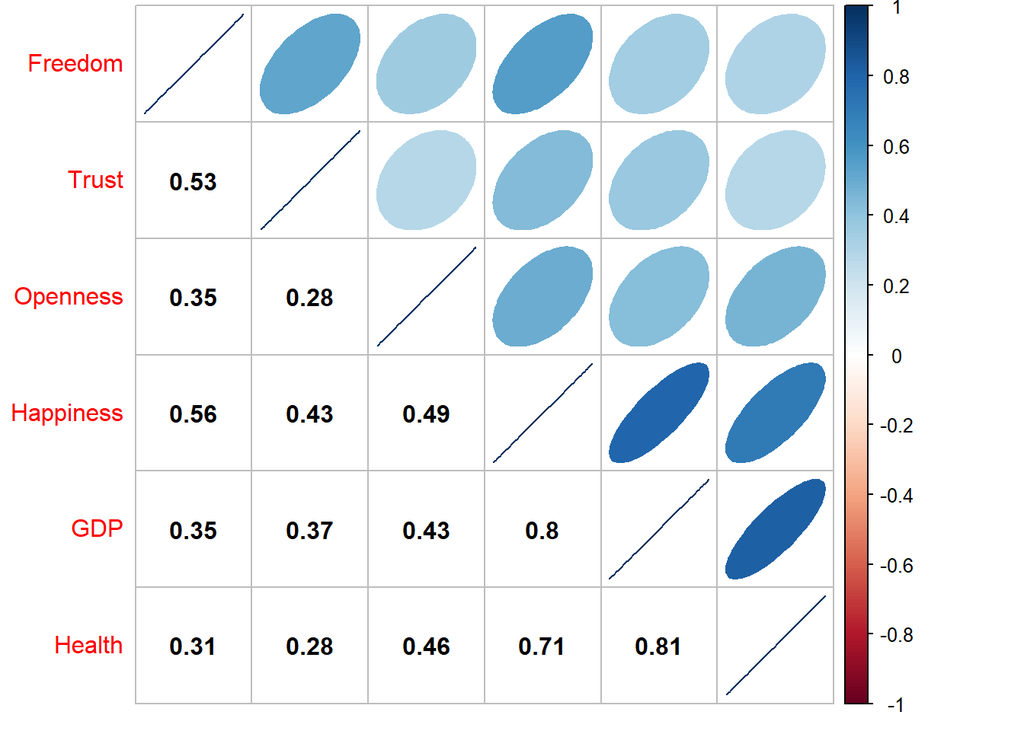

```r
# 相關性
library(corrplot)
corrplot(cor(analysis), method = 'ellipse', order = 'hclust', addrect = 6,
         type = 'upper', tl.pos = 'tp')
corrplot(cor(analysis), add = TRUE, type = 'lower', method = 'number',
         order = 'hclust', col = 'black', diag = FALSE, tl.pos = 'n', cl.pos = 'n')
```

```r
# 解釋5個變項
summary(m4 <- lm(GDP ~ Happiness + Openness + Freedom + Trust + Health, data = analysis))
```

```
##
## Call:
## lm(formula = GDP ~ Happiness + Openness + Freedom + Trust + Health,
##     data = analysis)
##
## Residuals:
##      Min       1Q   Median       3Q      Max
## -0.37450 -0.10134  0.00313  0.11060  0.80359
##
## Coefficients:
##               Estimate Std. Error t value Pr(>|t|)
## (Intercept) -0.4341459  0.0909824  -4.772 5.55e-06 ***
## Happiness    0.1614450  0.0252467   6.395 3.83e-09 ***
## Openness    -0.0003865  0.0009531  -0.405   0.6859
## Freedom     -0.2950965  0.1522289  -1.939   0.0551 .
## Trust        0.2691023  0.1606062   1.676   0.0966 .
## Health       0.8229009  0.1118687   7.356 3.36e-11 ***
## ---
## Signif. codes:  0 '***' 0.001 '**' 0.01 '*' 0.05 '.' 0.1 ' ' 1
##
## Residual standard error: 0.1889 on 112 degrees of freedom
## Multiple R-squared:  0.7695, Adjusted R-squared:  0.7592
## F-statistic: 74.77 on 5 and 112 DF,  p-value: < 2.2e-16
```

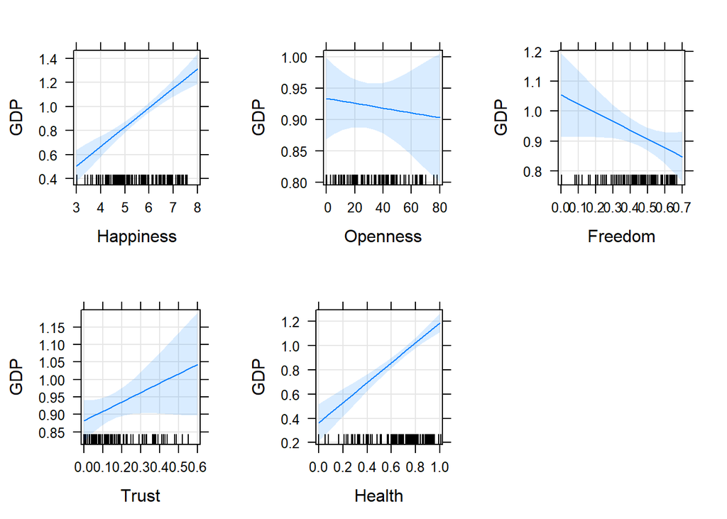

```r
# 相關性繪圖
library(effects)
plot(allEffects(m4), main = '', grid = T)
```

```r
library(lm.beta)
summary(lm.beta(m4))
```

```
##
## Call:
## lm(formula = GDP ~ Happiness + Openness + Freedom + Trust + Health,
##     data = analysis)
##
## Residuals:
##      Min       1Q   Median       3Q      Max
## -0.37450 -0.10134  0.00313  0.11060  0.80359
##
## Coefficients:
##               Estimate Standardized Std. Error t value Pr(>|t|)
## (Intercept) -0.4341459    0.0000000  0.0909824  -4.772 5.55e-06 ***
## Happiness    0.1614450    0.4863999  0.0252467   6.395 3.83e-09 ***
## Openness    -0.0003865   -0.0217236  0.0009531  -0.405   0.6859
## Freedom     -0.2950965   -0.1164365  0.1522289  -1.939   0.0551 .
## Trust        0.2691023    0.0912521  0.1606062   1.676   0.0966 .
## Health       0.8229009    0.4886836  0.1118687   7.356 3.36e-11 ***
## ---
## Signif. codes:  0 '***' 0.001 '**' 0.01 '*' 0.05 '.' 0.1 ' ' 1
##
## Residual standard error: 0.1889 on 112 degrees of freedom
## Multiple R-squared:  0.7695, Adjusted R-squared:  0.7592
## F-statistic: 74.77 on 5 and 112 DF,  p-value: < 2.2e-16
```

# **Conclusion**

First, the tests tell us that the significance is strong between each region no matter what variables we choose in openness, happiness or GDP.  
Second, according to the scatter plots of ‘GDP & Region’, ‘Happiness & Region’,  
we conclude that there is a strong relationship between these two variables.  
Third, we made some plots about these two variables and confirmed the assumption.  
Finally, we add some new variables to the model and see their influnces on GDP.